# PROYECTO

PG1

Author

GRUPO 6

Published

October 11, 2026

# 1. Introducción

## 1.1 Relevancia

Este tema es importante porque la mayoría de estudiantes usa la IA diariamente para sus actividades académicas. Analizar este uso nos ayuda a saber con qué frecuencia la utilizan, para qué lo usan y en qué cursos hacen más consultas. También nos ayuda a ver si el uso de estas herramientas realmente les ayuda a comprender mejor los temas o a ahorrar tiempo. Además, consideraremos otros factores asociados a hábitos de los estudiantes, como las horas de sueño y horas efectivas de estudio, para determinar su influencia en el rendimiento académico.

## 1.2 Planificación

### Diagrama de Gantt

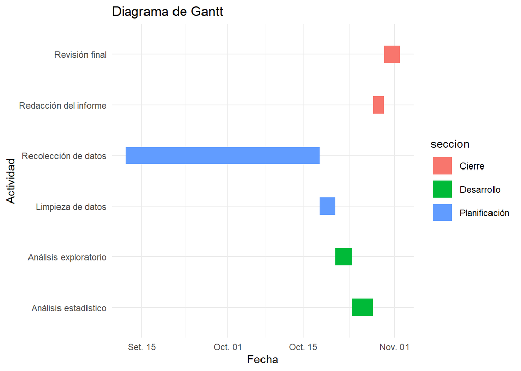

```r
library(ggplot2)

tareas <- data.frame(
  tarea = c(
    "Recolección de datos",
    "Limpieza de datos",
    "Análisis exploratorio",
    "Análisis estadístico",
    "Redacción del informe",
    "Revisión final"
  ),
  inicio = as.Date(c(
    "2026-09-12", "2026-10-18", "2026-10-21", "2026-10-24", "2026-10-28", "2026-10-30"
  )),
  fin = as.Date(c(
    "2026-10-18", "2026-10-21", "2026-10-24", "2026-10-28", "2026-10-30", "2026-11-02"
  )),
  seccion = c(
    "Planificación",
    "Planificación",
    "Desarrollo",
    "Desarrollo",
    "Cierre",
    "Cierre"
  )
)

ggplot(tareas,
       aes(x = inicio,
           xend = fin,
           y = tarea,
           yend = tarea,
           color = seccion)) +
  geom_segment(linewidth = 8) +
  labs(title = "Diagrama de Gantt",
       x = "Fecha",
       y = "Actividad") +
  theme_minimal()
```

## 1.3 Objetivos

### 1.3.1 Objetivo general

Analizar el impacto de las horas de sueño y el uso de IA en el rendimiento académico de lo estudiantes UTEC de Estadística sección 1 durante el ciclo 2026-2.

### 1.3.2 Objetivos específicos

1. Analizar la existencia de alguna relación entre la frecuencia diaria de consultas a la Inteligencia Artificial y el Nivel de satisfacción con el avance académico diario. Análisis bivariado: “N° consultas a IA realizada ese día” y “Nivel de satisfacción con el avance académico diario”
2. Analizar si existe alguna correlación entre el número de consultas a la IA en un cierto día y la cantidad de horas dedicadas al estudio. Se usarán las variables “N° de consultas a IA realizadas ese día” y “Suma de horas efectivas de estudio”.
3. Identificar si el curso de mayor consulta influye en el principal uso que se le da a la Inteligencia Artificial ese día y determinar qué usos generan mayor número de tareas con tiempo ahorrado. Para este caso se usará doble análisis bivariado. (“curso sobre el cual se hicieron la mayoría de consultas de IA” vs “Principal uso de IA ese día”) y (“Principal uso de IA ese día” vs “N° de tareas ese día en las que usar IA le ahorró tiempo”)
4. Determinar si existe una relación entre las horas de sueño de la noche anterior y el nivel de comprensión de las actividades académicas realizadas durante el día. Se usará un análisis bivariado a las variables “Horas de sueño de la noche anterior” y “Nivel de comprensión de las actividades académicas realizadas ese día”.

# 2. Datos

## 2.1 Población objetivo

Estudiantes universitarios de UTEC durante el semestre 2026-2 que cursan la materia de Estadística y Probabilidades de la sección 01.

### 2.1.1 Unidad muestral

Está conformada por los estudiantes universitarios evaluados de forma individual y diaria. A cada uno de ellos se le aplicará un registro de datos para medir su comportamiento diario, su rendimiento académico y su relación con el uso de Inteligencia Artificial (en la tabla principal).

Además se contará con dos tablas externas:

“Tabla Exámenes”: en la que cada registro tenga los datos de cada examen tomado por el estudiante. En este caso, cada examen es la unidad muestral.

“Tabla Demográfica”: la que contará con los datos de los estudiantes que son invariantes en el ciclo. Para esta tabla, cada estudiante también sería la unidad muestral.

### 2.1.2 Representatividad de la muestra

Con la finalidad de que la muestra obtenida refleje a la población y se minimicen posibles sesgos, se plantean las siguientes medidas:

Cobertura total de la sección: El instrumento de medición se aplicará en un aula específica, de modo que todos los integrantes contarán con acceso diario al formulario y así evitando el sesgo de no respuesta

Medición al cierre del día: El cuestionario se realizará al final de cada día el cual permitirá registra las variables diarias (como las horas de estudio o el uso de IA), atenuando el sesgo de memoria. El registro de un día se contará como válido si este se hace después de las 9:30 p.m. pero antes de la medianoche.

## 2.2 Tipo de muestreo

Se utilizará un muestreo sistemático por conveniencia, estructurado bajo un diseño de recolección de datos de tipo longitudinal . Esta decisión responde a la exigencia del estudio, el cual requiere que los estudiantes reporten sus métricas académicas, de sueño y de uso de Inteligencia Artificial de forma diaria. El diseño longitudinal generará múltiples observaciones repetidas por cada estudiante, otorgándole al estudio una solidez estadística necesaria para capturar patrones de comportamiento consistentes en el tiempo.

## 2.3 Recolección de datos

Se diseñarán 3 formularios (Google Forms) diferentes. Uno será para los datos demográficos (solo se rellenará una vez por estudiante), otro para el diario (se rellenará una vez por día) y otro para los exámenes (se rellenará una vez por cada examen tomado).

## 2.4 Variables

### 2.4.1 Consideración de los tipos de variables

| Variable | Tipo general | Subtipo |
| --- | --- | --- |
| N° de consultas a IA realizadas ese día | Cuantitativa | Discreta |
| Principal uso de IA ese día | Cualitativa | Nominal |
| Nivel de satisfacción con el avance académico diario | Cualitativa | Ordinal |
| N° de tareas ese día en las que usar IA le ahorró tiempo | Cuantitativa | Discreta |
| curso sobre el cual se hicieron la mayoría de consultas de IA | Cualitativa | Nominal |
| Suma de horas efectivas de estudio | Cuantitativa | Continua |
| Horas de sueño de la noche anterior | Cuantitativa | Continua |
| Nivel de comprensión de las actividades académicas realizadas ese día | Cualitativa | Ordinal |

### 2.4.2 Libreta de códigos (codebook / restricciones)

| Variable | Restricción / Rango o categorías válidas |
| --- | --- |
| N° consultas a IA realizada ese día | x >= 0 |
| Nivel de satisfacción con el avance académico diario | Likert 5 niveles: Muy baja → Muy alta |
| Suma de horas efectivas de estudio | x >= 0 |
| curso sobre el cual se hicieron la mayoría de consultas de IA | Texto libre |
| Principal uso de IA ese día | resumir, resolver ejercicios, redactar, programar, otros |
| N° de tareas ese día en las que usar IA le ahorró tiempo | x >= 0 |
| Horas de sueño de la noche anterior | 0 <= x <= 24 |
| Nivel de comprensión de las actividades académicas realizadas ese día | Muy bajo, Bajo, Moderado, Alto, Muy alto |

### 2.4.3 Mediciones

Cada variable va a ser registrada en el formulario de Google Forms, el cual contendrá todas las restricciones de valores que puede tomar la variable dependiendo de su tipo y de su naturaleza.

## 2.5 Limpieza

### Paso 0: Obtener el conjunto de datos

```r
library(readr)
library(dplyr)
library(tidyverse)
library(ggplot2)

DF <- read_csv("RespuestasDiario.csv")
```

```r
names(DF)
```

```
 [1] "Marca temporal"
 [2] "¿Cuántas consultas a una IA realizaste hoy?"
 [3] "¿Qué nivel de confianza tienes en las respuestas de la IA sin verificarlas?"
 [4] "¿Cuál fue el uso principal que le diste a la IA hoy?"
 [5] "¿Cuántas horas dormiste la noche pasada?"
 [6] "¿Con qué frecuencia estudiaste hoy?"
 [7] "¿A cuántas clases no asististe hoy?"
 [8] "¿Qué nivel de satisfacción tienes con tu avance académico de hoy?"
 [9] "¿Qué material utilizaste más para estudiar hoy?"
[10] "¿Cuántas horas dedicaste exclusivamente a trabajos grupales o proyectos hoy?"
[11] "¿Qué nivel de comprensión tuviste de las actividades académicas que realizaste hoy?"
[12] "¿Cuál fue tu sensación principal después de usar la IA hoy?"
[13] "¿En cuántas tareas de hoy el uso de la IA te ahorró tiempo?"
[14] "¿Cuál es el código del curso sobre el que hiciste la mayoría de tus consultas a la IA hoy?"
[15] "¿Cuántas horas efectivas de estudio acumulaste el día de hoy?"
[16] "Dirección de correo electrónico"
```

```r
DFL <- DF
```

Renombramos las columnas que utilizaremos

```r
DFL %>% rename(hora = `Marca temporal`
               , consultas = `¿Cuántas consultas a una IA realizaste hoy?`
               , uso = `¿Cuál fue el uso principal que le diste a la IA hoy?`
               , satisfaccion = `¿Qué nivel de satisfacción tienes con tu avance académico de hoy?`
               , tareas = `¿En cuántas tareas de hoy el uso de la IA te ahorró tiempo?`
               , curso = `¿Cuál es el código del curso sobre el que hiciste la mayoría de tus consultas a la IA hoy?`
               , estudio = `¿Cuántas horas efectivas de estudio acumulaste el día de hoy?`
               , sueno = `¿Cuántas horas dormiste la noche pasada?`
               , comprension = `¿Qué nivel de comprensión tuviste de las actividades académicas que realizaste hoy?`
               , email = `Dirección de correo electrónico`) -> DFL
```

Nos quedamos con las columnas de nuestros objetivos específicos.

```r
DFL <- DFL[, c("hora", "consultas", "uso", "satisfaccion", "tareas", "curso", "estudio", "sueno", "comprension", "email")]
names(DFL)
```

```
 [1] "hora"         "consultas"    "uso"          "satisfaccion" "tareas"
 [6] "curso"        "estudio"      "sueno"        "comprension"  "email"
```

Obtenemos los grupos que han aportado en base a los correos que tenemos y en base a una tabla auxiliar

```r
DFAuxiliar <- read_csv("CorreosGrupo.csv")
```

Realizamos un inner join para relacionar `email` con el grupo correspondiente

```r
DFL <- inner_join(DFL, DFAuxiliar, by = "email")
```

```r
head(DFL[c("hora", "email", "Grupo")])
```

```
# A tibble: 6 × 3
  hora                email                     Grupo
  <chr>               <chr>                     <dbl>
1 12/09/2026 14:07:28 camila.alfaro@utec.edu.pe     5
2 12/09/2026 17:50:32 angelo.urbina@utec.edu.pe     8
3 12/09/2026 21:33:05 camila.alfaro@utec.edu.pe     5
4 12/09/2026 21:41:39 eduardo.vila@utec.edu.pe      6
5 12/09/2026 21:45:53 andre.merino@utec.edu.pe      9
6 12/09/2026 22:14:13 indira.yabar@utec.edu.pe      6
```

### Vista del subset final

```r
dim(DFL)
```

```
[1] 356  11
```

```r
head(DFL)
```

```
# A tibble: 6 × 11
  hora       consultas uso   satisfaccion tareas curso estudio sueno comprension
  <chr>          <dbl> <chr>        <dbl>  <dbl> <chr>   <dbl> <dbl> <chr>
1 12/09/202…         9 Resu…            4      1 CS40…       3  9    Alto
2 12/09/202…         0 El d…            3      2 ME20…       1  5    Moderado
3 12/09/202…        13 Resu…            3      1 CS40…       3  9    Alto
4 12/09/202…         2 Inve…            4      1 CS20…       4  8.33 Muy alto
5 12/09/202…         4 Resu…            3      1 GI31…       1  8    Moderado
6 12/09/202…        32 Resu…            3      0 CS20…       7  7    Moderado
# ℹ 2 more variables: email <chr>, Grupo <dbl>
```

```r
sapply(DFL, class)
```

```
        hora    consultas          uso satisfaccion       tareas        curso
 "character"    "numeric"  "character"    "numeric"    "numeric"  "character"
     estudio        sueno  comprension        email        Grupo
   "numeric"    "numeric"  "character"  "character"    "numeric"
```

### Paso 1: Radiografía de la base

Cantidad de NA por columna:

```r
colSums(is.na(DFL))
```

```
        hora    consultas          uso satisfaccion       tareas        curso
           0            0            2            0            0            2
     estudio        sueno  comprension        email        Grupo
           0            0            0            0            0
```

Porcentaje de NA por columna:

```r
round(colSums(is.na(DFL)) / nrow(DFL) * 100, 2)
```

```
        hora    consultas          uso satisfaccion       tareas        curso
        0.00         0.00         0.56         0.00         0.00         0.56
     estudio        sueno  comprension        email        Grupo
        0.00         0.00         0.00         0.00         0.00
```

Se puede ver que hay 4 valores faltantes en el dataframe. Esto es raro considerando que el formulario original tiene todas las preguntas marcadas como obligatorias.

#### Análisis de ceros

```r
sum(DFL$consultas == 0, na.rm = TRUE)
```

```
[1] 26
```

Al analizar la variable `consultas` (cantidad de consultas realizadas a la IA durante un día), se puede ver que en los tantos días ya transcurridos han habido a lo mucho 26 personas que no han usa la IA un día entero.

```r
sum(DFL$tareas == 0, na.rm = TRUE)
```

```
[1] 70
```

En la variable `tareas` (cantidad de tareas que la IA ha ayudado a resolver más rápidamente) se nota que han habido a lo mucho 70 personas a las cuales la IA no les ha ayudado a resolver ni una sola tarea en un cierto día.

```r
sum(DFL$estudio == 0, na.rm = TRUE)
```

```
[1] 21
```

En la variable `estudio` (Horas efectivas de estudio en un día) han habido a lo mucho 21 estudiantes que no han estudiado durante un día entero.

```r
sum(DFL$sueno == 0, na.rm = TRUE)
```

```
[1] 3
```

En la variable `sueno` (cantidad de horas de sueño de la noche anterior al día del registro en el formulario) se ve que ya han habido 3 estudiantes que se han pasado despiertos desde la noche hasta la mañana del día siguiente.

#### Análisis de cardinalidad

```r
length(unique(DFL$comprension))
```

```
[1] 5
```

```r
unique(DFL$comprension)
```

```
[1] "Alto"     "Moderado" "Muy alto" "Bajo"     "Muy bajo"
```

La variable categórica ordinal de 5 niveles `comprension` ya ha tomado cada uno de los 5 valores por lo menos una vez.

```r
length(unique(DFL$sueno))
```

```
[1] 30
```

```r
unique(DFL$sueno)
```

```
 [1]  9.0000  5.0000  8.3300  8.0000  7.0000 10.0000  6.0000  8.1600  4.0000
[10]  3.0000  7.5000  7.6600  6.6600  6.5000  3.5000 13.0000  8.5000  2.0000
[19]  8.4500 11.0000  7.6555  4.1700  4.5000  9.8000  0.0000  9.4000  1.0000
[28]  8.2000 10.5000 14.0000
```

La variable `sueno` ha tomado varios valores a pesar de la discretización parcial de la variable y al hecho de que [0, 24] es el rango de valores admisibles.

```r
length(unique(DFL$estudio))
```

```
[1] 26
```

```r
unique(DFL$estudio)
```

```
 [1]  3.00  1.00  4.00  7.00  2.00  0.00  3.70  9.00  5.00  1.20  6.00  1.50
[13]  0.66  4.20  2.83  1.58  2.42  0.50  5.20  3.50  2.33  1.17  8.00 13.00
[25]  2.50 10.00
```

La variable `estudio` ha tomado varios valores a pesar de la discretización parcial de la variable y al hecho de que [0, 24] es el rango de valores admisibles.

```r
length(unique(DFL$curso))
```

```
[1] 81
```

```r
unique(DFL$curso)
```

```
 [1] "CS4054"
 [2] "ME2014"
 [3] "CS2031"
 [4] "GI3101"
 [5] "CS2041"
 [6] "CC1105"
 [7] "EL3012"
 [8] "-"
 [9] "ninguno"
[10] "CS2013"
[11] "CI2012"
[12] "CS1015"
[13] "CC6201"
[14] "HH6002"
[15] "CI2021"
```

[output cut: 66 more lines]

En el caso de `curso`, esta ya presenta una gran variabilidad debido a que la UTEC dicta varios cursos y los alumnos de Estadística provienen de varias carreras.

```r
length(unique(DFL$tareas))
```

```
[1] 12
```

```r
unique(DFL$tareas)
```

```
 [1]  1  2  0  3  4  5 15  6  7 11 12  8
```

La variable discreta `tareas` ha tomado una cantidad reducida de valores encerrados en el intervalo [0, 15].

```r
length(unique(DFL$satisfaccion))
```

```
[1] 5
```

```r
unique(DFL$satisfaccion)
```

```
[1] 4 3 1 2 5
```

La categórica ordinal `satisfaccion` ya ha tomado cada uno de sus 5 valores posibles.

```r
length(unique(DFL$uso))
```

```
[1] 39
```

```r
unique(DFL$uso)
```

```
 [1] "Resumir"                      "El día de hoy no usé IA"
 [3] "Investigar"                   "Agendara recordatorio"
 [5] "Revisar conceptos"            "Ninguno"
 [7] "No la usé"                    "Resolver ejercicios"
 [9] "Programar"                    "No use ia hoy"
[11] "profundizar conceptos"        "Consultar"
[13] "Redactar"                     "Traducir y entender idiomas"
[15] "investigar temas"             "consulta medica"
[17] "No usé"                       "Buscar herramientas"
[19] "Ayudarme a encontrar errores" "revisar conceptos"
[21] "no lo use"                    NA
[23] "Nada"                         "Ninguna"
[25] "No use IA"                    "repasar"
[27] "Ayudar a aprender"            "Aprender"
[29] "Una pregunta al azar"         "No usé IA"
[31] "Repasar"                      "Explicar temas"
[33] "Traducir"                     "No use idea"
[35] "Aprender inglés"              "nothing"
[37] "preguntas de conceptos"       "Dudas cotidianas"
[39] "-"
```

La variable categórica `uso` (principal uso que se le dio a la IA en un cierto día) también presenta gran variabilidad gracias a su naturaleza nominal.

```r
length(unique(DFL$consultas))
```

```
[1] 53
```

```r
unique(DFL$consultas)
```

```
 [1]  9  0 13  2  4 32 20  5 68 15 12 26  6  3  8 18 50 40 29 10 27  7 49  1 33
[26] 30 35 14 42 19 54 37 28 25 22 48 31 11 21 56 41 43 45 17 16 36 34 38 57 52
[51] 47 23 60
```

En cuanto a la variable discreta `consultas`, se puede ver la gran variabilidad que tiene en sus valores.

### Paso 2: Normalización

Se filtrará con base en el plazo de tiempo para el envío del formulario. Además, se tendrán en cuenta los valores que pudieron evadir las restricciones iniciales, por lo que se aplicarán verificaciones de valores vacíos en las columnas de consultas, tareas, estudio y sueno, junto con la validación de valores enteros.

```r
#Se hace el filtrado por horas teniendo en cuenta que se guarda en el formato de 24 horas por lo que solo acotamos desde 21.5 osea 9:30

DFL1<-DFL%>%filter(!(((hour(dmy_hms(hora)) + minute(dmy_hms(hora))/60) < 21.5))) %>%

# en caso de superesswarnings es para evitar que arroje errores en consultas debido a que permite ingreso de datos vacios por lo que se trata de convertir a numero y de ahi vemos si es NA e inviertiendo mediante ! para quedarnos con los que si cumplan eso

filter(!is.na(suppressWarnings(as.numeric(consultas))),

# Repetimos el mismo tipo de filtrado con respecto a la variable tareas, sueno y estudio

!is.na(suppressWarnings(as.numeric(tareas))),
!is.na(suppressWarnings(as.numeric(estudio))),                           !is.na(suppressWarnings(as.numeric(sueno))))%>%

#verificamos que las consultas y tareas sean numeros enteros

filter(as.numeric(consultas)%%1==0,
       as.numeric(tareas)%%1==0)
```

### Paso 3: Aplicación de criterios (validación de rangos)

Como la respuesta cualitativa (uso) se relaciona con variables cuantitativas (consultas y tareas), para evitar la pérdida de la fila debido a los datos contradictorios, los valores no válidos se reasignarán con NA.

```r
  DF2<-DFL1%>%mutate(

  # se arma el primer filtro para normalizar uso
  uso_= chartr("áéíóúÁÉÍÓÚ", "aeiouAEIOU", tolower(uso)),

  # el segundo filtro para la busqueda de palabras clave
  usoC= str_detect(uso_,regex("\\b(ia|no|use|ningun[oa])\\b",ignore_case = TRUE)),

  # el tercer filtro ayuda a buscar datos no validos y validar los mismos
  cursoC = is.na(curso) | str_detect(curso, "^[ -]*$") |
  str_detect(curso, "^[A-Za-z]{2}\\d{4}$"),

  # el cuarto filtro verifica las consultas y une con validacion de curso
  filtro=!usoC&cursoC&(as.numeric(consultas)>0|as.numeric(tareas)>0),

  # se aplica el filtro para cada dato relacionado
  uso = if_else(filtro, uso,NA_character_),

  consultas=if_else(filtro,consultas,NA_integer_),

  tareas= if_else(filtro,tareas,NA_integer_),

  curso = if_else(filtro,curso,NA_character_)
  ) %>% select(-filtro, -usoC,-cursoC,-uso_)
# despues se borra las columnas auxiliares
```

### Paso 4: Datos atípicos

Para identificar posibles valores atípicos utilizamos boxplots en las variables numéricas.

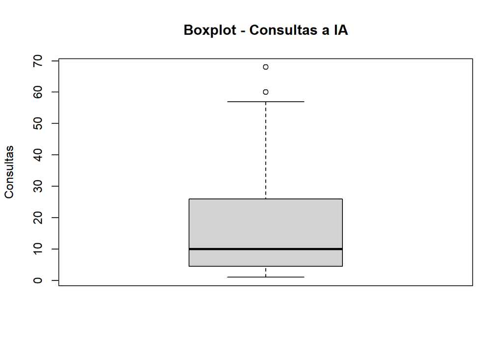

```r
# Número de consultas a IA
boxplot(DF2$consultas,
        main = "Boxplot - Consultas a IA",
        ylab = "Consultas")
```

```r
boxplot.stats(DF2$consultas)$out
```

```
[1] 68 60
```

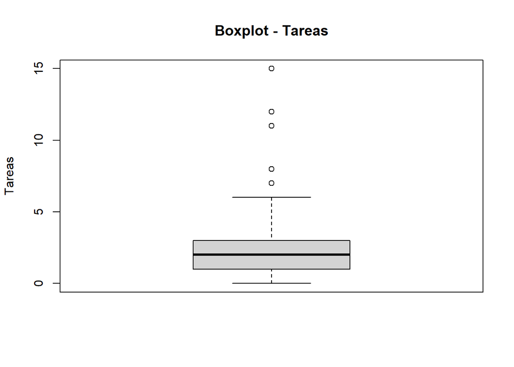

```r
# Número de tareas donde la IA ahorró tiempo
boxplot(DF2$tareas,
        main = "Boxplot - Tareas",
        ylab = "Tareas")
```

```r
boxplot.stats(DF2$tareas)$out
```

```
[1] 15  7 11 12 11  8
```

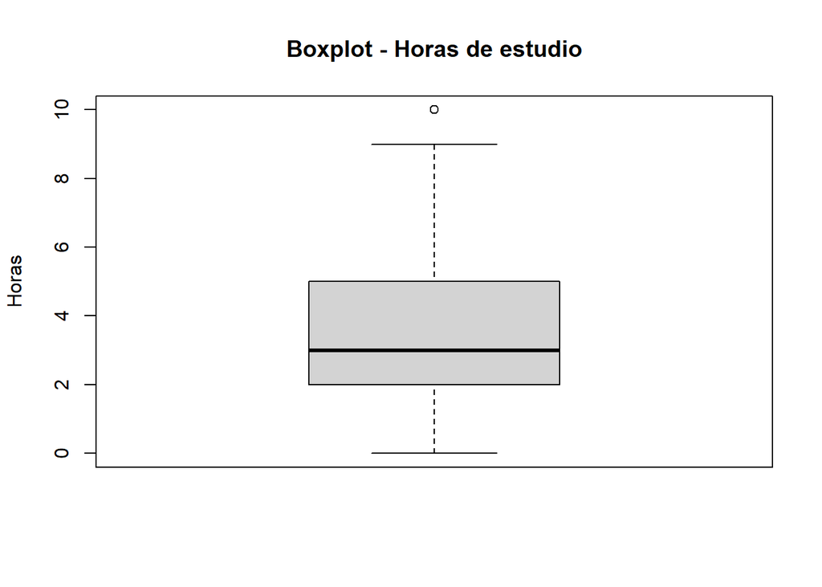

```r
# Horas efectivas de estudio
boxplot(DF2$estudio,
        main = "Boxplot - Horas de estudio",
        ylab = "Horas")
```

```r
boxplot.stats(DF2$estudio)$out
```

```
[1] 10
```

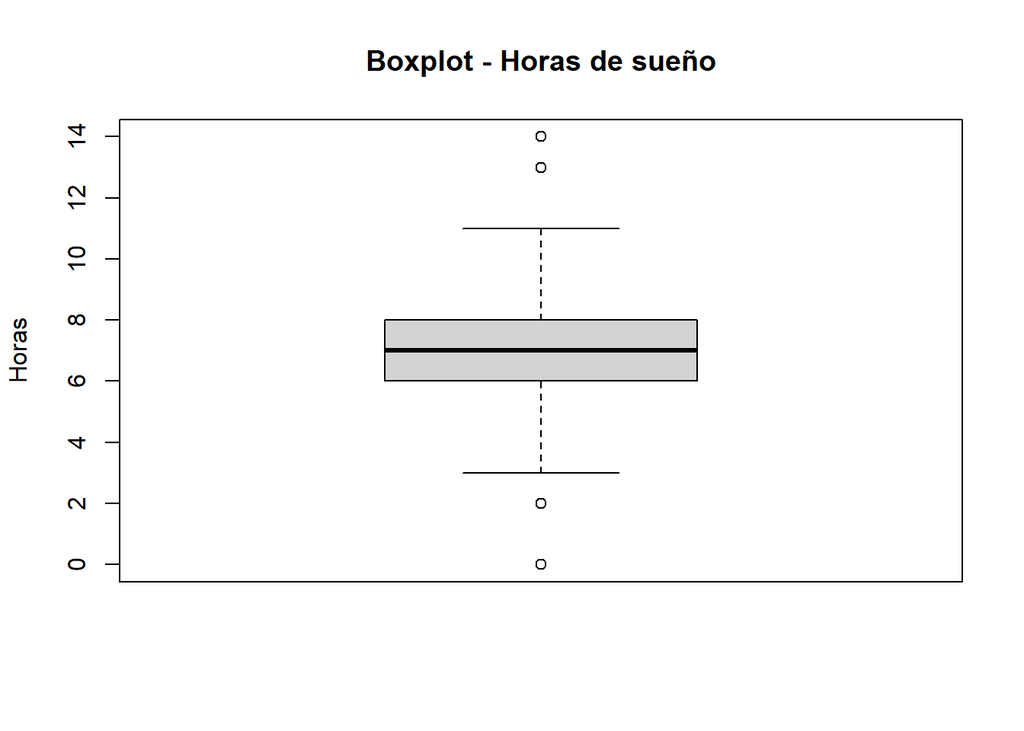

```r
# Horas de sueño
boxplot(DF2$sueno,
        main = "Boxplot - Horas de sueño",
        ylab = "Horas")
```

```r
boxplot.stats(DF2$sueno)$out
```

```
[1] 13  2  2  2  2  0  0  0 14
```

### Paso 5: Variabilidad

Para cada una de las variables numéricas calculamos el rango, la varianza, la desviación estándar y el IQR.

```r
# Variabilidad de las consultas
range(DF2$consultas, na.rm = TRUE)
```

```
[1]  1 68
```

```r
var(DF2$consultas, na.rm = TRUE)
```

```
[1] 213.9431
```

```r
sd(DF2$consultas, na.rm = TRUE)
```

```
[1] 14.62679
```

```r
IQR(DF2$consultas, na.rm = TRUE)
```

```
[1] 21.25
```

```r
# Variabilidad de las tareas
range(DF2$tareas, na.rm = TRUE)
```

```
[1]  0 15
```

```r
var(DF2$tareas, na.rm = TRUE)
```

```
[1] 4.01017
```

```r
sd(DF2$tareas, na.rm = TRUE)
```

```
[1] 2.002541
```

```r
IQR(DF2$tareas, na.rm = TRUE)
```

```
[1] 2
```

```r
# Variabilidad de las horas de estudio
range(DF2$estudio, na.rm = TRUE)
```

```
[1]  0 10
```

```r
var(DF2$estudio, na.rm = TRUE)
```

```
[1] 3.773968
```

```r
sd(DF2$estudio, na.rm = TRUE)
```

```
[1] 1.94267
```

```r
IQR(DF2$estudio, na.rm = TRUE)
```

```
[1] 3
```

```r
# Variabilidad de las horas de sueño
range(DF2$sueno, na.rm = TRUE)
```

```
[1]  0 14
```

```r
var(DF2$sueno, na.rm = TRUE)
```

```
[1] 3.780192
```

```r
sd(DF2$sueno, na.rm = TRUE)
```

```
[1] 1.944272
```

```r
IQR(DF2$sueno, na.rm = TRUE)
```

```
[1] 2
```

```r
# Frecuencia del principal uso de IA
table(DF2$uso)
```

```
       Agendara recordatorio              Aprender inglés
                           1                            1
Ayudarme a encontrar errores          Buscar herramientas
                           1                            1
                   Consultar               Explicar temas
                           2                            1
                  Investigar             investigar temas
                           3                            1
      preguntas de conceptos        profundizar conceptos
                           1                            1
                   Programar                     Redactar
                          61                           14
                     repasar          Resolver ejercicios
                           1                           85
                     Resumir            revisar conceptos
                          70                            1
           Revisar conceptos                     Traducir
                           1                            2
```

```r
prop.table(table(DF2$uso)) * 100
```

```
       Agendara recordatorio              Aprender inglés
                   0.4032258                    0.4032258
Ayudarme a encontrar errores          Buscar herramientas
                   0.4032258                    0.4032258
                   Consultar               Explicar temas
                   0.8064516                    0.4032258
                  Investigar             investigar temas
                   1.2096774                    0.4032258
      preguntas de conceptos        profundizar conceptos
                   0.4032258                    0.4032258
                   Programar                     Redactar
                  24.5967742                    5.6451613
                     repasar          Resolver ejercicios
                   0.4032258                   34.2741935
                     Resumir            revisar conceptos
                  28.2258065                    0.4032258
           Revisar conceptos                     Traducir
                   0.4032258                    0.8064516
```

```r
# Frecuencia del nivel de satisfacción
table(DF2$satisfaccion)
```

```
  1   2   3   4   5
 19  26 135  96  14
```

```r
prop.table(table(DF2$satisfaccion)) * 100
```

```
        1         2         3         4         5
 6.551724  8.965517 46.551724 33.103448  4.827586
```

```r
# Frecuencia del nivel de comprensión
table(DF2$comprension)
```

```
    Alto     Bajo Moderado Muy alto Muy bajo
      84       17      159       20       10
```

```r
prop.table(table(DF2$comprension)) * 100
```

```
     Alto      Bajo  Moderado  Muy alto  Muy bajo
28.965517  5.862069 54.827586  6.896552  3.448276
```

### Paso 6: Gestión de nulos

Tras los filtros iniciales, los valores nulos (NA) se concentran en cuatro variables sobre IA. A continuación, se evalúa el impacto de una eliminación directa.

```r
tabla_NA <- data.frame(
  Variable = names(DF2),
  Cantidad_NA = colSums(is.na(DF2)),
  Porcentaje_NA = round(colSums(is.na(DF2)) / nrow(DF2) * 100, 2),
  row.names = NULL
)
tabla_NA
```

```
       Variable Cantidad_NA Porcentaje_NA
1          hora           0          0.00
2     consultas          42         14.48
3           uso          42         14.48
4  satisfaccion           0          0.00
5        tareas          42         14.48
6         curso          42         14.48
7       estudio           0          0.00
8         sueno           0          0.00
9   comprension           0          0.00
10        email           0          0.00
11        Grupo           0          0.00
```

```r
#Revisamos si los NAs están en una mismo registro
table(rowSums(is.na(DF2)))
```

```
  0   4
248  42
```

```r
#Impacto si eliminamos los NAs
nrow(DF2)
```

```
[1] 290
```

```r
nrow(na.omit(DF2))
```

```
[1] 248
```

```r
round((1 - nrow(na.omit(DF2)) / nrow(DF2)) * 100, 2)
```

```
[1] 14.48
```

```r
# DF2 sale de DFL1 sin filtrar filas, así que ambas bases están alineadas
# podemos recuperar de DFL1 los valores que el Paso 3 convirtió a NA.
nrow(DFL1) == nrow(DF2)
```

```
[1] TRUE
```

```r
diagnostico <- DF2 %>%
  mutate(
    # Valores originales, antes del Paso 3
    consultas_orig = as.numeric(DFL1$consultas),
    tareas_orig    = as.numeric(DFL1$tareas),
    uso_orig       = as.character(DFL1$uso),
    curso_orig     = as.character(DFL1$curso),

    # ¿El estudiante declaró alguna actividad con IA ese día?
    hubo_actividad = consultas_orig > 0 | tareas_orig > 0,

    # Motivo por el que el registro quedó incompleto
    motivo = case_when(
      !is.na(uso)     ~ "Completo",
      !hubo_actividad ~ "Sin uso de IA",
      TRUE            ~ "Curso fuera de formato"
    )
  )

table(diagnostico$motivo)
```

```
              Completo Curso fuera de formato          Sin uso de IA
                   248                     23                     19
```

Se identificaron dos mecanismos que exigen un tratamiento diferenciado para no sesgar los datos:

```r
# Perfil de cada grupo según las consultas que realmente declararon
diagnostico %>%
  filter(motivo != "Completo") %>%
  group_by(motivo) %>%
  summarise(
    n = n(),
    consultas_min   = min(consultas_orig),
    consultas_max   = max(consultas_orig),
    consultas_media = round(mean(consultas_orig), 1)
  )
```

```
# A tibble: 2 × 5
  motivo                     n consultas_min consultas_max consultas_media
  <chr>                  <int>         <dbl>         <dbl>           <dbl>
1 Curso fuera de formato    23             0            30             6.3
2 Sin uso de IA             19             0             0             0
```

Una política uniforme asignaría `consultas = 0` y `uso = "No usó IA"` a estudiantes con uso intensivo, sesgando las variables centrales de los objetivos 1 y 3.

| Motivo | Tratamiento | Justificación |
| --- | --- | --- |
| Sin uso de IA | `consultas` y `tareas` → 0; `uso` → “No usó IA”; `curso` → “No aplica” | El valor real del conteo es cero y la ausencia es una respuesta lógica |
| Curso fuera de formato | Se conservan `consultas`, `tareas` y `uso`; solo `curso` → “Sin código válido” | El uso de IA sí ocurrió; lo único inválido es el código del curso |

Se agrega `uso_ia` para que los objetivos 1 y 3 puedan filtrar los días sin uso sin eliminarlos. También se codifican las variables ordinales como factor y los identificadores como nominales.

```r
DF3 <- diagnostico %>%
  mutate(
    # Marca si de verdad usó IA, según el motivo y no según si había NA
    uso_ia = motivo != "Sin uso de IA",

    # Si no usó IA, el valor verdadero es 0
    # Cuantitativas discretas:
    consultas = if_else(motivo == "Sin uso de IA", 0, consultas_orig),
    consultas= as.integer(consultas),
    tareas    = if_else(motivo == "Sin uso de IA", 0, tareas_orig),
    tareas= as.integer(tareas),

    # Cualitativa nominal: asignamos una categoría propia
    uso   = if_else(motivo == "Sin uso de IA", "No usó IA", uso_orig),
    uso = factor(uso,levels=unique(uso)),


  # Si solo falló el curso, se conservan sus datos reales
  # y únicamente el curso queda marcado como inválido
    curso = case_when(
      motivo == "Sin uso de IA"          ~ "No aplica",
      motivo == "Curso fuera de formato" ~ "Sin código válido",
      TRUE                               ~ curso_orig
    ),
      curso = factor(curso,levels=unique(curso)),

    # Cuantitativas continuas
    estudio = as.numeric(estudio),
    sueno   = as.numeric(sueno),

    # Ordinal, levels imponen el orden
    comprension = factor(comprension,
                         levels = c("Muy bajo", "Bajo", "Moderado", "Alto", "Muy alto"),
                         ordered = TRUE),

    satisfaccion = factor(satisfaccion, levels = 1:5, ordered = TRUE),

    # Identificador: el promedio de un número de grupo no tendría interpretación
    Grupo = factor(Grupo)
  ) %>%
# Se borran las columnas que solo sirvieron para el diagnóstico
  select(-consultas_orig, -tareas_orig, -uso_orig, -curso_orig,
         -hubo_actividad, -motivo)
```

```r
# Verificamos que no quede ningún NA ni se hayan perdido filas
sum(is.na(DF3))
```

```
[1] 1
```

```r
nrow(DF3)
```

```
[1] 290
```

```r
table(DF3$uso_ia)
```

```
FALSE  TRUE
   19   271
```

### paso 7: Radiografia final

```r
# Cuántas observaciones sobreviven a cada etapa del proceso
trazabilidad <- data.frame(
  Etapa = c("Base cruda (DF)", "Subset y join (DFL)", "Normalización (DFL1)",
            "Criterios (DF2)", "Gestión de nulos (DF3)"),
  Observaciones = c(nrow(DF), nrow(DFL), nrow(DFL1), nrow(DF2), nrow(DF3))
)
# Qué porcentaje de la base original representa cada etapa
trazabilidad$Retencion <- round(trazabilidad$Observaciones / nrow(DF) * 100, 2)
trazabilidad
```

```
                   Etapa Observaciones Retencion
1        Base cruda (DF)           356    100.00
2    Subset y join (DFL)           356    100.00
3   Normalización (DFL1)           290     81.46
4        Criterios (DF2)           290     81.46
5 Gestión de nulos (DF3)           290     81.46
```

```r
# Mismo diagnóstico del Paso 1, ahora sobre la base limpia.
radiografia <- data.frame(
  Variable = names(DF3),
  Tipo = sapply(DF3, function(x) class(x)[1]),
  NA_total = colSums(is.na(DF3)),
  Porcentaje_NA = round(colSums(is.na(DF3)) / nrow(DF3) * 100, 2),
  Unicos = sapply(DF3, function(x) length(unique(x))),
  row.names = NULL
)
radiografia
```

```
       Variable      Tipo NA_total Porcentaje_NA Unicos
1          hora character        0          0.00    290
2     consultas   integer        0          0.00     52
3           uso    factor        1          0.34     23
4  satisfaccion   ordered        0          0.00      5
5        tareas   integer        0          0.00     12
6         curso    factor        0          0.00     44
7       estudio   numeric        0          0.00     24
8         sueno   numeric        0          0.00     29
9   comprension   ordered        0          0.00      5
10        email character        0          0.00     34
11        Grupo    factor        0          0.00      9
12       uso_ia   logical        0          0.00      2
```

```r
# Conteo de ceros en cada numérica
sum(DF3$consultas == 0)
```

```
[1] 22
```

```r
sum(DF3$tareas == 0)
```

```
[1] 59
```

```r
sum(DF3$estudio == 0)
```

```
[1] 16
```

```r
sum(DF3$sueno == 0)
```

```
[1] 3
```

```r
# Verificamos que ninguna numérica se salga de los rangos del codebook.

data.frame(
  Variable = c("consultas", "tareas", "estudio", "sueno"),
  Restriccion = c("x >= 0", "x >= 0", "x >= 0", "0 <= x <= 24"),
  Minimo = c(min(DF3$consultas), min(DF3$tareas), min(DF3$estudio), min(DF3$sueno)),
  Maximo = c(max(DF3$consultas), max(DF3$tareas), max(DF3$estudio), max(DF3$sueno)),
  Cumple = c(all(DF3$consultas >= 0), all(DF3$tareas >= 0), all(DF3$estudio >= 0),
             all(DF3$sueno >= 0 & DF3$sueno <= 24))
)
```

```
   Variable  Restriccion Minimo Maximo Cumple
1 consultas       x >= 0      0     68   TRUE
2    tareas       x >= 0      0     15   TRUE
3   estudio       x >= 0      0     10   TRUE
4     sueno 0 <= x <= 24      0     14   TRUE
```

Todas las variables cumplen los rangos del codebook. Los valores extremos corresponden a los atípicos validados en el Paso 4.

```r
# Filas idénticas en todas sus columnas
sum(duplicated(DF3))
```

```
[1] 0
```

```r
# El diseño es longitudinal, cada estudiante debe tener un solo registro por día.
DF3 %>%
  mutate(fecha = substr(hora, 1, 10)) %>%
  count(email, fecha) %>%
  filter(n > 1)
```

```
# A tibble: 2 × 3
  email                      fecha          n
  <chr>                      <chr>      <int>
1 alvaro.pacheco@utec.edu.pe 17/09/2026     2
2 samuel.abril@utec.edu.pe   17/09/2026     2
```

Se detectaron 2 registros duplicados. Al no poder determinar el válido, se documentan para futuras correcciones del instrumento.

```r
# Observaciones limpias que aportó cada grupo
DF3 %>% count(Grupo)
```

```
# A tibble: 9 × 2
  Grupo     n
  <fct> <int>
1 1        32
2 2        16
3 3        55
4 4        22
5 5        27
6 6        64
7 7        14
8 8        17
9 9        43
```

```r
# Filtro sobre nuestro grupo
GRUPO <- 6
DF3_grupo <- DF3 %>% filter(Grupo == GRUPO)

nrow(DF3_grupo)
```

```
[1] 64
```

```r
DF3_grupo %>% count(email)
```

```
# A tibble: 5 × 2
  email                          n
  <chr>                      <int>
1 dervy.pillaca@utec.edu.pe     11
2 eduardo.vila@utec.edu.pe      15
3 indira.yabar@utec.edu.pe      14
4 johan.huayta@utec.edu.pe       4
5 mathius.quispe@utec.edu.pe    20
```

```r
n_distinct(DF3$email)
```

```
[1] 34
```

# 3. Análisis descriptivo

## 3.1 Análisis univariado: consultas

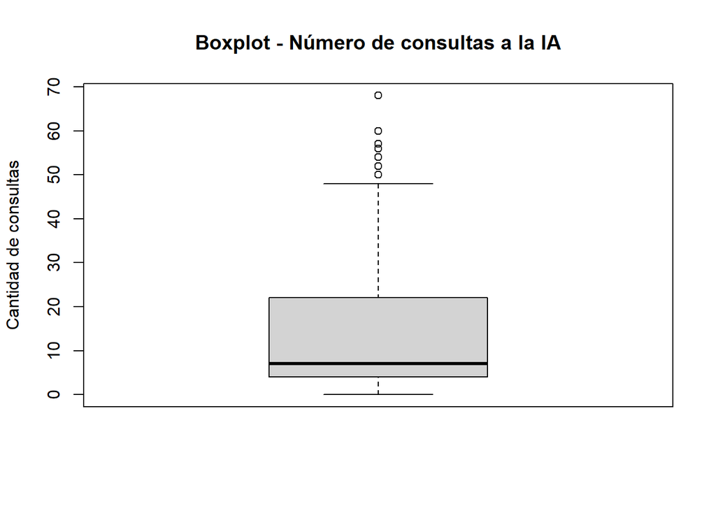

```r
boxplot(DF3$consultas,
        main = "Boxplot - Número de consultas a la IA",
        ylab = "Cantidad de consultas")
```

```r
quantile(DF3$consultas, 0.5, na.rm = T, type = 3, )
```

```
50%
  7
```

```r
quantile(DF3$consultas, 0.75, na.rm = T, type = 3, )
```

```
75%
 22
```

Se puede ver que en al menos la mitad de los registros, el estudiante hace 7 o más consultas diarias a la IA, lo que indica un uso frecuente de esta herramienta. Esto se ve reforzado al notar que, en por lo menos un cuarto de los registros, los estudiante han hecho 22 o más consultas diarias a la IA.

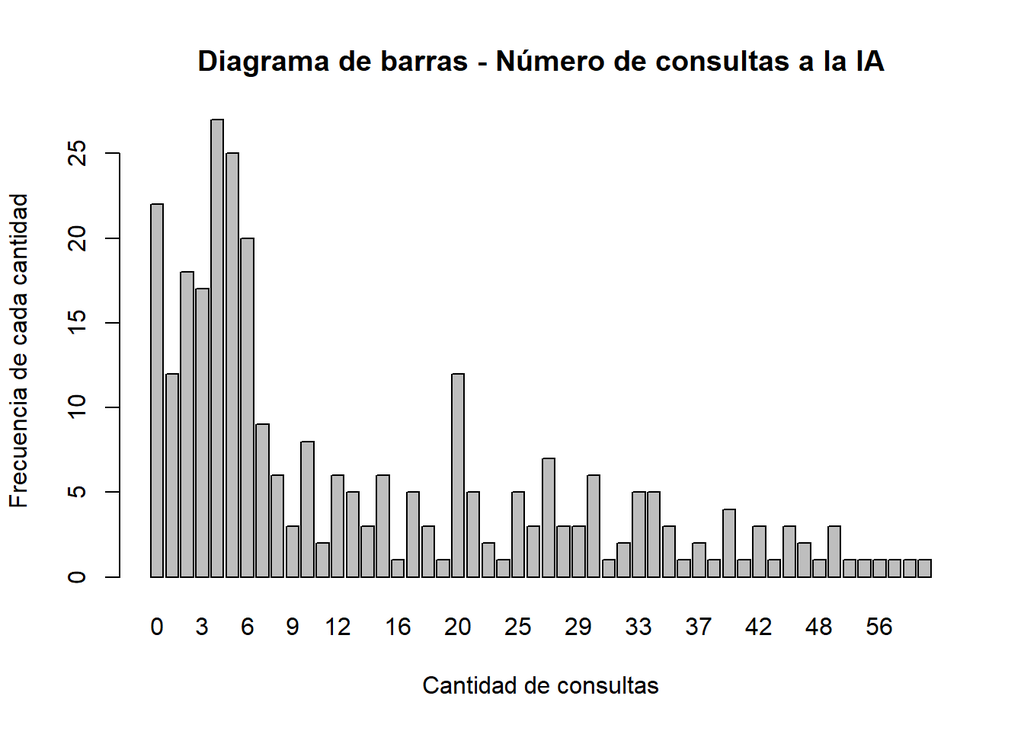

```r
barplot(table(DF3$consultas),
        main = "Diagrama de barras - Número de consultas a la IA",
        xlab = "Cantidad de consultas",
        ylab = "Frecuencia de cada cantidad")
```

En el barplot se ve que si bien en la mayoría de registros el estudiante no hace un uso intensivo de la IA, este uso sí es constante en el tiempo.

## 3.2 Análisis univariado: comprension

Al ser ordinal, usamos frecuencias, porcentajes y barras. No hay media ni desviación porque no son números, pero sí mediana porque tienen orden.

```r
table(DF3$comprension)
```

```
Muy bajo     Bajo Moderado     Alto Muy alto
      10       17      159       84       20
```

```r
round(prop.table(table(DF3$comprension)) * 100, 2)
```

```
Muy bajo     Bajo Moderado     Alto Muy alto
    3.45     5.86    54.83    28.97     6.90
```

```r
round(cumsum(prop.table(table(DF3$comprension))) * 100, 2)
```

```
Muy bajo     Bajo Moderado     Alto Muy alto
    3.45     9.31    64.14    93.10   100.00
```

### Gráfico

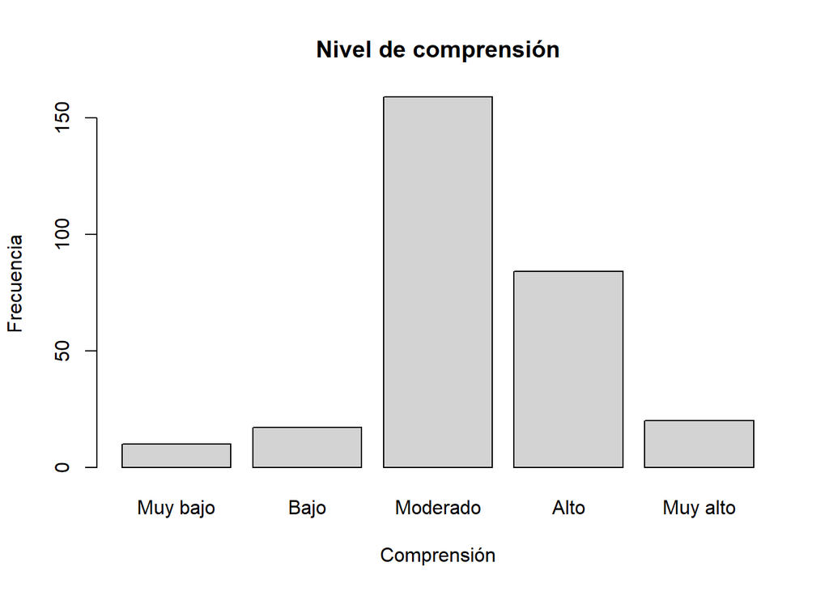

```r
barplot(table(DF3$comprension),
        main = "Nivel de comprensión",
        xlab = "Comprensión",
        ylab = "Frecuencia",
        col = "lightgray")
```

## 3.3 Análisis univariado: sueno

Al ser `sueno` una variable cuantitativa continua, se eligieron boxplot e histograma para describirla.

### Gráfico

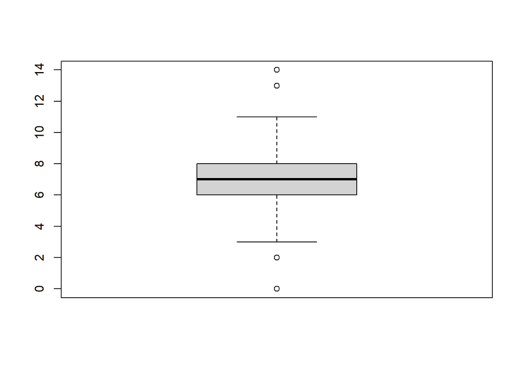

```r
boxplot(DF3$sueno)
```

La variable `sueno` muestra un patrón equilibrado entre los estudiantes de UTEC: la mitad duerme 7 horas o menos, y el 50% central concentra su descanso entre las 6 y 8 horas.

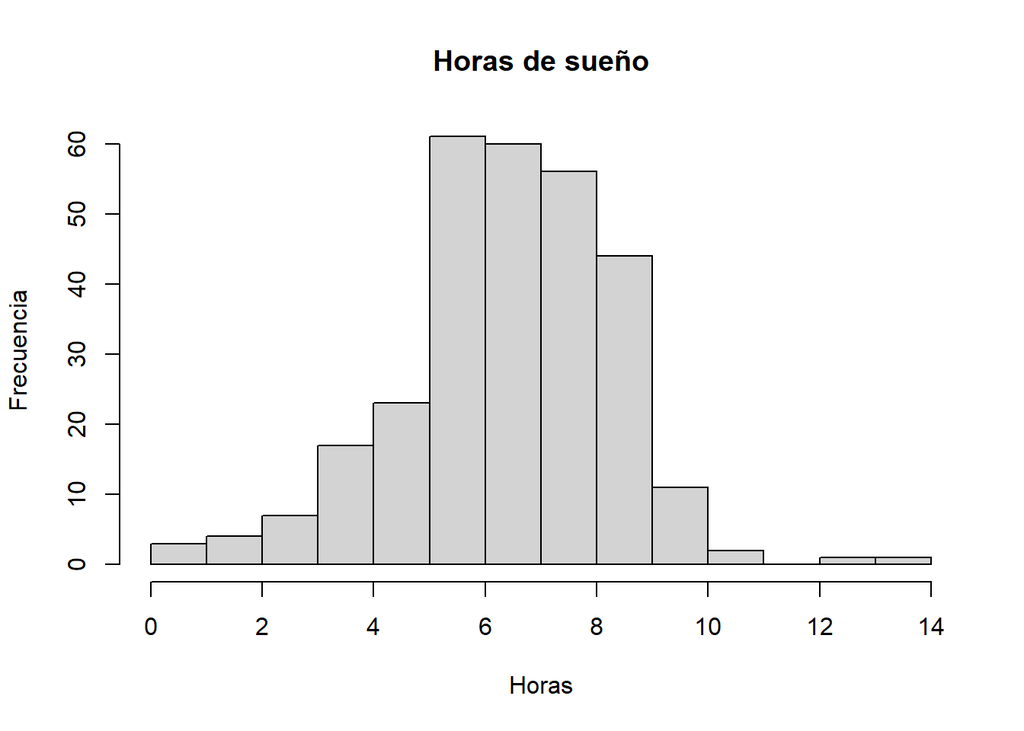

```r
hist(DF3$sueno,
     main = "Horas de sueño",
     xlab = "Horas",
     col = "lightgray",
     ylab = "Frecuencia")
```

El histograma confirma ese equilibrio, la mayoría de los estudiantes duerme un número similar de horas, y son pocos los que se alejan bastante del resto.

```r
summary(DF3$sueno)
```

```
   Min. 1st Qu.  Median    Mean 3rd Qu.    Max.
  0.000   6.000   7.000   6.862   8.000  14.000
```

```r
round(sd(DF3$sueno),2)
```

```
[1] 1.94
```

```r
IQR(DF3$sueno)
```

```
[1] 2
```

```r
round(sd(DF3$sueno) / mean(DF3$sueno),2) #CV
```

```
[1] 0.28
```

## 3.4 Análisis multivariado (cruces según objetivos)

### Objetivo 1: consultas vs. satisfaccion

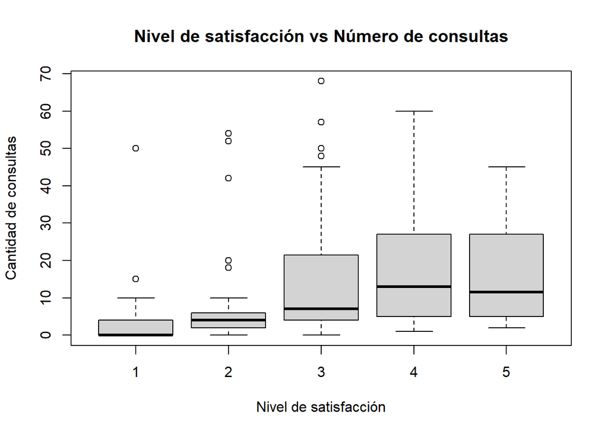

```r
boxplot(consultas ~ satisfaccion, data = DF3,
        main = "Nivel de satisfacción vs Número de consultas",
        xlab = "Nivel de satisfacción",
        ylab = "Cantidad de consultas")
```

Al comparar el nivel de satisfacción de estudio diario con la cantidad de consultas realizadas a la IA, se puede notar un claro incremento en la mediana de `consultas` de acuerdo al incremento del nivel de satisfacción (excepto en el nivel 5 de satisfacción, donde se ve una disminución de la mediana). Esto nos indica que podría haber una relación importante entre cuántas consultas se ha hecho a la IA y cuán satisfecho se está con el estudio de ese día.

```r
quantile(DF3$consultas[DF3$satisfaccion == 3], 0.3, na.rm = T, type = 3)
```

```
30%
  5
```

```r
quantile(DF3$consultas[DF3$satisfaccion == 4], 0.3, na.rm = T, type = 3)
```

```
30%
  6
```

```r
quantile(DF3$consultas[DF3$satisfaccion == 5], 0.3, na.rm = T, type = 3)
```

```
30%
  5
```

Se puede notar que al menos el 70% de los registros de cada categoría de satisfacción “positiva” (3, 4, 5) incluye 5 o más consultas a la IA por día.

### Objetivo 2: consultas vs. estudio

```r
cor.test(DF3$consultas,DF3$estudio,method="spearman")
```

```
    Spearman's rank correlation rho

data:  DF3$consultas and DF3$estudio
S = 2109221, p-value < 2.2e-16
alternative hypothesis: true rho is not equal to 0
sample estimates:
      rho
0.4810989
```

Se usó el coeficiente de correlación de Spearman debido a que resiste mejor la presencia de outliers, el cual fue de 0.481, lo que confirma una asociación positiva y moderada, además de que con el p-value < 0.001 podemos asegurar significancia estadística, ya que indica que no es resultado de azar. En conclusión, hay una tendencia de que a mayor cantidad de horas de estudio habrá más consultas que se realizaron.

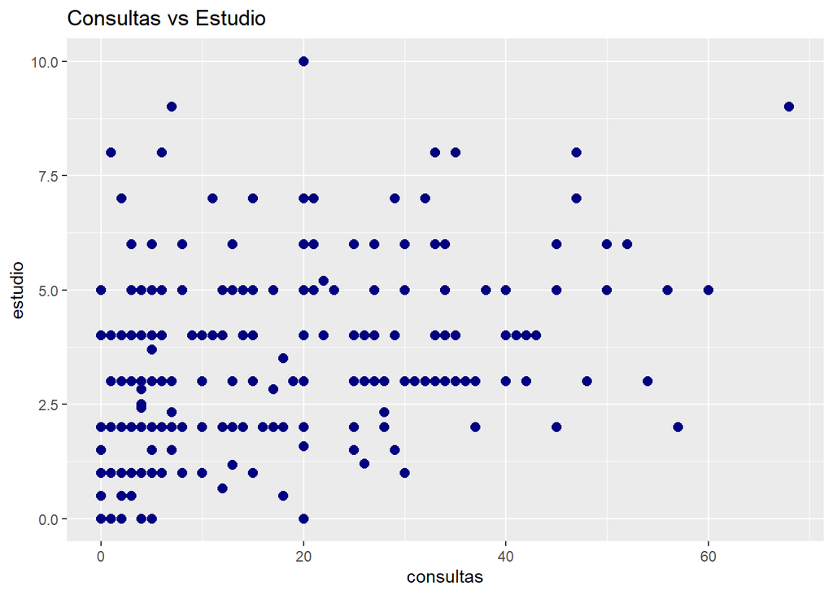

```r
ggplot(DF3, aes(x = consultas, y = estudio)) +
  geom_point(color = "navy", size = 2.5) +
  labs(
    title = "Consultas vs Estudio",
    x = "consultas",
    y = "estudio"
  )
```

### Objetivo 3:

### Objetivo 3a: curso vs. uso

Al ser ambas nominales, usamos tabla cruzada, porcentajes por curso, barras y mosaico. Quitamos los días sin uso de IA y dejamos los 4 cursos y 4 usos más frecuentes.

```r
DFC <- DF3[DF3$uso_ia == TRUE, ]
DFC$curso <- toupper(DFC$curso)
DFC$uso <- as.character(DFC$uso)
DFC <- DFC[DFC$curso %in% c("CC1105", "CS2031", "CC2101", "CS2013"), ]
DFC <- DFC[DFC$uso %in% c("Resolver ejercicios", "Resumir", "Programar", "Redactar"), ]
nrow(DFC)
```

```
[1] 116
```

```r
tabla <- table(DFC$curso, DFC$uso)
tabla
```

```
         Programar Redactar Resolver ejercicios Resumir
  CC1105        20        6                  18       6
  CC2101         1        1                  11       3
  CS2013         8        0                   4       8
  CS2031        15        1                   1      13
```

```r
round(prop.table(tabla, 1) * 100, 2)
```

```
         Programar Redactar Resolver ejercicios Resumir
  CC1105     40.00    12.00               36.00   12.00
  CC2101      6.25     6.25               68.75   18.75
  CS2013     40.00     0.00               20.00   40.00
  CS2031     50.00     3.33                3.33   43.33
```

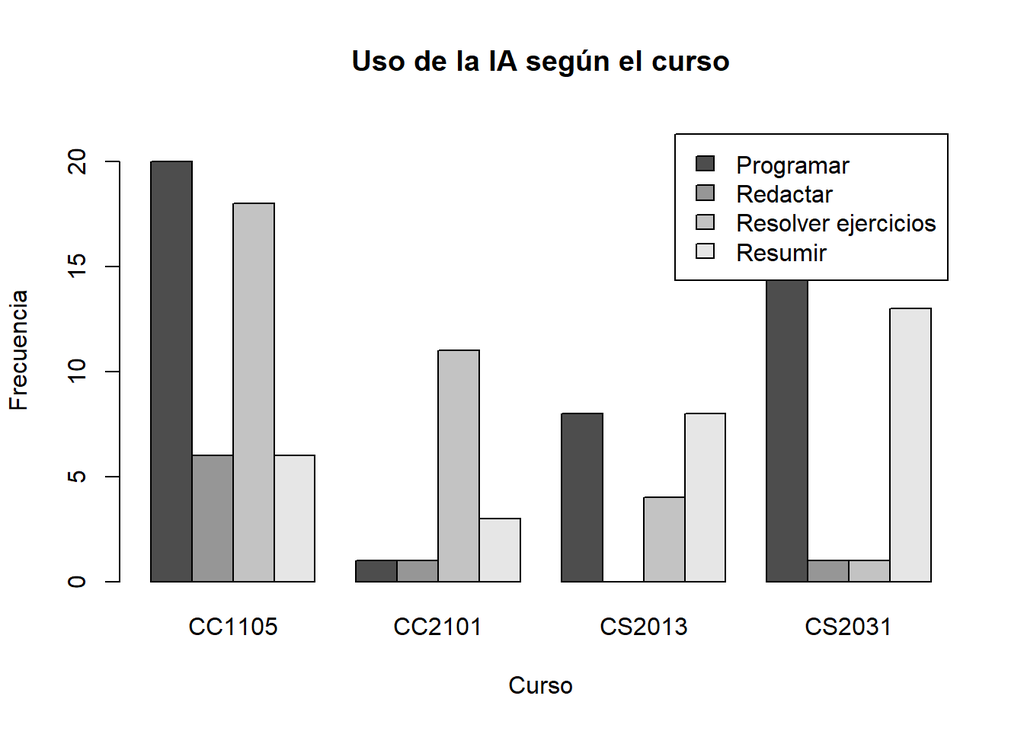

```r
barplot(t(tabla),
        beside = TRUE,
        legend.text = TRUE,
        main = "Uso de la IA según el curso",
        xlab = "Curso",
        ylab = "Frecuencia",
        ylim = c(0, 22))
```

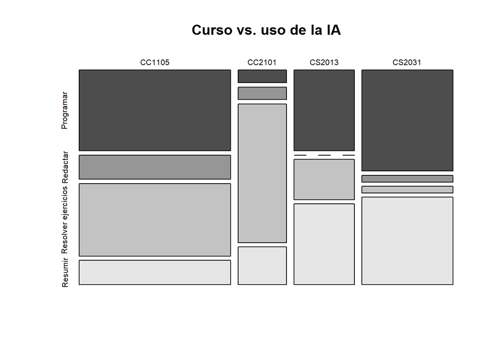

```r
mosaicplot(tabla,
           main = "Curso vs. uso de la IA",
           color = TRUE)
```

### Objetivo 3b: uso vs. tareas

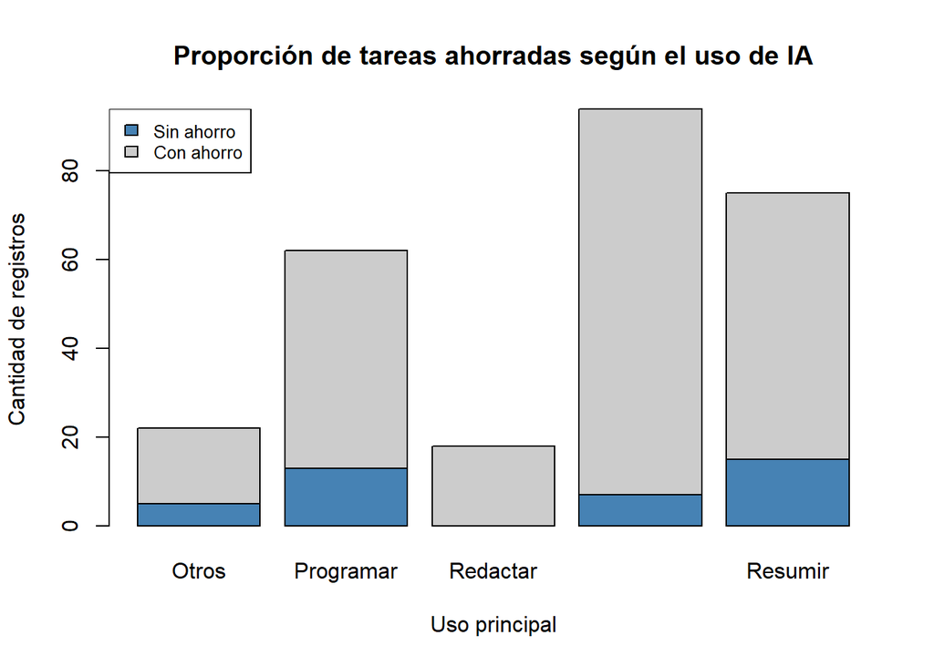

```r
DF3 %>%
  filter(uso_ia) %>%
  mutate(
    uso_g = if_else(uso %in% c("Resolver ejercicios", "Resumir",
                                "Programar", "Redactar", "No usó IA"),
                     as.character(uso), "Otros"),
    ahorro = if_else(tareas == 0, "Sin tareas ahorradas", "Con tareas ahorradas")
  ) %>%
  count(uso_g, ahorro) %>%
  tidyr::pivot_wider(names_from = ahorro, values_from = n, values_fill = 0) %>%
  {
    tabla <- .[, c("uso_g", "Sin tareas ahorradas", "Con tareas ahorradas")]
    m <- t(as.matrix(tabla[, -1]))
    colnames(m) <- tabla$uso_g
    barplot(m,
            main = "Proporción de tareas ahorradas según el uso de IA",
            ylab = "Cantidad de registros",
            xlab = "Uso principal",
            col = c("steelblue", "gray80"))
    legend("topleft",
           legend = c("Sin ahorro", "Con ahorro"),
           fill = c("steelblue", "gray80"),
           cex = 0.8)
  }
```

```r
DF3 %>%
  filter(uso_ia) %>%
  mutate(uso_g = if_else(uso %in% c("Resolver ejercicios", "Resumir",
                                     "Programar", "Redactar", "No usó IA"),
                          as.character(uso), "Otros")) %>%
  group_by(uso_g) %>%
  summarise(
    registros   = n(),
    ta_ahorrada = round(mean(tareas > 0, na.rm = TRUE) * 100, 1)
  ) %>%
  rename(Uso = uso_g)
```

```
# A tibble: 5 × 3
  Uso                 registros ta_ahorrada
  <chr>                   <int>       <dbl>
1 Otros                      22        77.3
2 Programar                  62        79
3 Redactar                   18       100
4 Resolver ejercicios        94        92.6
5 Resumir                    75        80
```

### Objetivo 4: comprension vs. sueno

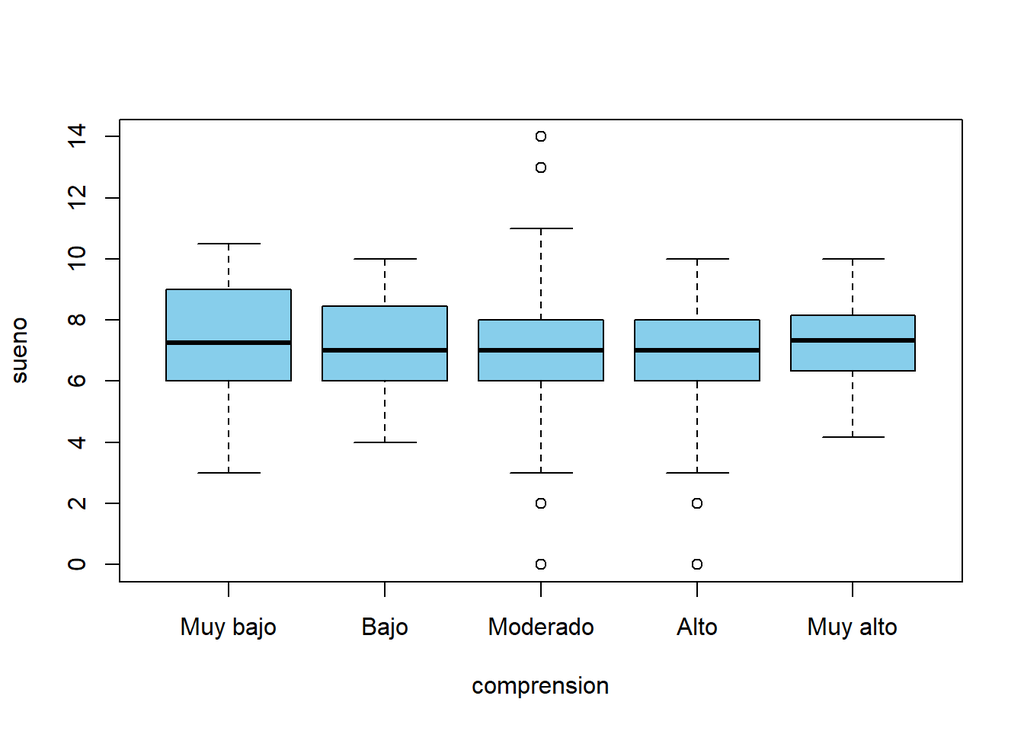

```r
boxplot(sueno ~ comprension, data = DF3,
        xlab = "comprension",
        ylab = "sueno",
        col = c("skyblue"))
```

```r
DF3%>%group_by(comprension)%>% summarise(n=n(),
    Q1= quantile(sueno, 0.25, na.rm = TRUE),
    Mediana = quantile(sueno, 0.5 ,na.rm = TRUE),
    Q3= quantile(sueno, 0.75, na.rm = TRUE),
    RIC     = IQR(sueno, na.rm = TRUE),
    Media = mean(sueno,na.rm=TRUE),
    CV = (sd(sueno,na.rm=TRUE)/mean(sueno,na.rm=TRUE))
                                         )
```

```
# A tibble: 5 × 8
  comprension     n    Q1 Mediana    Q3   RIC Media    CV
  <ord>       <int> <dbl>   <dbl> <dbl> <dbl> <dbl> <dbl>
1 Muy bajo       10  6       7.25  8.88  2.88  7.15 0.344
2 Bajo           17  6       7     8.45  2.45  7.32 0.237
3 Moderado      159  6       7     8     2     6.85 0.297
4 Alto           84  6       7     8     2     6.65 0.273
5 Muy alto       20  6.50    7.33  8.08  1.59  7.32 0.223
```

El 25% (Q1) en las 3 categorías intermedias tiene el mismo valor, mientras que en el 50% se mantiene esto, en el 50% central en las 2 categorías intermedias (Moderado, Alto), las horas de sueño varían de 6 a 8.

### Conclusión del Objetivo 1

Como se ha mencionado anteriormente, existe una relación positiva entre el número de consultas a la IA y el grado de satisfacción en el intervalo [1 : 4]. Se propone la explicación de que esta relación se podría deber a que un mayor número de consultas ayudan al estudiante a comprender mejor los temas que estudia. Esto derivaría en un mayor grado de satisfacción con el avance académico. Para el grado de satisfacción 5, si bien no sigue esta tendencia, aún tiene una relación con la variable `consultas` pues se sabe que al menos el 70% de sus registros reportan por lo menos 5 consultas a la IA por día.

Cabe aclarar que la propuesta de explicación presentada, la cual sigue un formato causa - consecuencia, es tan solo una hipótesis pues la existencia de una relación no implica causalidad.

### Conclusión del Objetivo 2

Se comprobó la asociación entre consultas y horas de estudio, la cual es positiva y moderada. Esto demuestra que a mayor cantidad de horas de estudio hay mayor cantidad de consultas.

### Conclusión del Objetivo 4

Sintetizando, se evidencia una relación inversa y leve entre las horas de sueño y la comprensión. Este comportamiento se puede observar mejor en la media de las categorías intermedias (Moderado, Alto), aunque pierde consistencia ya en los extremos debido a la cantidad de datos que las conforman.

### Conclusión general del estudio

Después de limpiar los datos, vimos que los estudiantes de Estadística sección 1 usan la IA casi todos los días y para cosas distintas según el curso. Los que hacen más consultas suelen estudiar más horas y sentirse más satisfechos con su avance. En cambio, las horas de sueño casi no cambian según el nivel de comprensión. Esto no prueba que una cosa cause la otra, solo que suelen darse juntas.